# Discovering Bias in Data

**Le'Shawn Sears**

M.S. Computer Science – Vanderbilt University

Responsible AI / XAI

Fall 2025

## Overview

This investigation examines statistical bias within the Mental Health in Tech Survey dataset through exploratory data analysis and fairness metrics. The goal was to determine whether demographic and workplace attributes could introduce bias into machine learning predictions and to identify features that may require careful consideration in responsible AI development.

To support accurate statistical interpretation, the analysis environment was configured to preserve full output visibility, ensuring fairness metrics and subgroup distributions could be examined without truncation.

```python
import logging
import numpy
import numpy as np
import pandas as pd
from math import *
from datetime import datetime
from operator import itemgetter
from zipfile import ZipFile
from io import BytesIO
import pickle
from urllib.request import urlopen

from IPython.display import Image
import matplotlib.pyplot as plt
import seaborn as sns
import plotly.express as px

from numpy import inf
from scipy.stats import kurtosis, skew

from sklearn.metrics import accuracy_score
from sklearn.model_selection import train_test_split
from sklearn import ensemble
from sklearn.metrics import confusion_matrix
from sklearn.metrics import classification_report
from sklearn.metrics import roc_auc_score
from sklearn import metrics
from sklearn.linear_model import LogisticRegression
from sklearn.linear_model import LinearRegression
from sklearn.metrics import average_precision_score
from sklearn.metrics import mean_squared_error



import warnings

from startistical_parity_calc import stat_parity_test

warnings.filterwarnings('ignore')
```

```python
pd.options.display.max_rows = 4000
```

```python
from pandas.api.types import CategoricalDtype
```

Loading and preparing the data

```python
# data = pd.read_csv('RAIdata.csv')
data = pd.read_csv('./survey.csv')
```

Exploring data

## 1. Data Preparation

- Converted the `treatment` column to numeric (`1` for 'Yes', `0` for 'No') for analysis.
- Dropped rows with missing values for `treatment` to ensure the outcome is defined for all cases.
- Removed unnecessary columns (`Timestamp`, `comments`, `state`) to focus on relevant features.
- Checked for remaining missing values to confirm the dataset is ready for further analysis.

```python
data.shape
```

```
(1259, 27)
```

```python
# data["Default"].value_counts()

# Convert to binary
data['treatment'] = data['treatment'].map({'Yes': 1, 'No': 0})
data["treatment"].value_counts()
```

```
treatment
1    637
0    622
Name: count, dtype: int64
```

```python
# Drop missing key columns
data = data.dropna(subset=['treatment'])

# Drop unnecessary columns
data = data.drop(columns=['Timestamp', 'comments', 'state'])

# Remove don't know option keeping only entries with benefits or not
data = data[data['benefits'].isin(['Yes', 'No'])]

# Check for null values
print(data.isnull().sum())
```

```
Age                            0
Gender                         0
Country                        0
self_employed                 11
family_history                 0
treatment                      0
work_interfere               150
no_employees                   0
remote_work                    0
tech_company                   0
benefits                       0
care_options                   0
wellness_program               0
seek_help                      0
anonymity                      0
leave                          0
mental_health_consequence      0
phys_health_consequence        0
coworkers                      0
supervisor                     0
mental_health_interview        0
phys_health_interview          0
mental_vs_physical             0
obs_consequence                0
dtype: int64
```

```python
import re

# Clean Gender column using regex as there are many misspelled or joke entries in the dataset
def normalize_gender(val):
    val = str(val).strip().lower()
    if re.search(r'\bfem(ale)?\b', val):
        return 'Female'
    if re.search(r'\bmale\b', val):
        return 'Male'
    return None

data['Gender'] = data['Gender'].apply(normalize_gender)
data = data[data['Gender'].isin(['Male', 'Female'])]
data['Gender'].value_counts()
```

```
Gender
Male      559
Female    136
Name: count, dtype: int64
```

```python
# Employement types
print(data["self_employed"].value_counts())
print(data["remote_work"].value_counts())
print(data["tech_company"].value_counts())
```

```
self_employed
No     588
Yes     97
Name: count, dtype: int64
remote_work
No     488
Yes    207
Name: count, dtype: int64
tech_company
Yes    564
No     131
Name: count, dtype: int64
```

```python
# Define age group
data['age_group'] = data['Age'].apply(lambda x: '<35' if x < 35 else '35+')
print(data['age_group'].value_counts())
```

```
age_group
<35    474
35+    221
Name: count, dtype: int64
```

```python
# Define country group
data['country_group'] = data['Country'].apply(lambda x: 'United States' if x == 'United States' else 'Other')
print(data['country_group'].value_counts())
```

```
country_group
United States    400
Other            295
Name: count, dtype: int64
```

```python
data.head().T
```

|  | 0 | 2 | 3 | 4 | 5 |
| --- | --- | --- | --- | --- | --- |
| Age | 37 | 32 | 31 | 31 | 33 |
| Gender | Female | Male | Male | Male | Male |
| Country | United States | Canada | United Kingdom | United States | United States |
| self_employed | NaN | NaN | NaN | NaN | NaN |
| family_history | No | No | Yes | No | Yes |
| treatment | 1 | 0 | 1 | 0 | 0 |
| work_interfere | Often | Rarely | Often | Never | Sometimes |
| no_employees | 6-25 | 6-25 | 26-100 | 100-500 | 6-25 |
| remote_work | No | No | No | Yes | No |
| tech_company | Yes | Yes | Yes | Yes | Yes |
| benefits | Yes | No | No | Yes | Yes |
| care_options | Not sure | No | Yes | No | Not sure |
| wellness_program | No | No | No | Don't know | No |
| seek_help | Yes | No | No | Don't know | Don't know |
| anonymity | Yes | Don't know | No | Don't know | Don't know |
| leave | Somewhat easy | Somewhat difficult | Somewhat difficult | Don't know | Don't know |
| mental_health_consequence | No | No | Yes | No | No |
| phys_health_consequence | No | No | Yes | No | No |
| coworkers | Some of them | Yes | Some of them | Some of them | Yes |
| supervisor | Yes | Yes | No | Yes | Yes |
| mental_health_interview | No | Yes | Maybe | Yes | No |
| phys_health_interview | Maybe | Yes | Maybe | Yes | Maybe |
| mental_vs_physical | Yes | No | No | Don't know | Don't know |
| obs_consequence | No | No | Yes | No | No |
| age_group | 35+ | <35 | <35 | <35 | <35 |
| country_group | United States | Other | Other | United States | United States |

Data bias detection

Definition:

### Statistical Parity Difference and Disparate Impact

**Probability of all groups under protected class to have same probability of favourable outcome**  
[Fairness Through Awareness](https://arxiv.org/pdf/1104.3913.pdf)

**Statistical Parity Difference:** $$ \begin{align} \mathbb{P}({Y} = 1 {|} \mathbf{S} = \mathbf{T}_{a}) = \mathbb{P}( {Y}=1{|}\mathbf{S} = \mathbf{T}_{d}) \end{align} $$

**Disparate Impact:**

## 2. Bias Detection: Statistical Parity and Disparate Impact

For each protected attribute, I measured the potential bias and likelihood of seeking mental health treatment using Statistical Parity Difference and Disparte Impact:

- **Gender**
- **Age Group**
- **Employment Type**: `remote`, `tech`, `self-employed`
- **Benefits**
- **Country**

```python
#0 if favourable [false, default = false]
#1 if unfavourable [true, default = True]
fav=0
unfav=int(not fav)
```

```python
INPUT_DATAFRAME = data.copy()
LABEL_NAME = 'treatment'

PROTECTED_FEATURES = [
    ('Gender', 'Male', 'Female'),
    ('age_group', '<35', '35+'),
    ('self_employed', 'No', 'Yes'),
    ('remote_work', 'No', 'Yes'),
    ('tech_company', 'No', 'Yes'),
    ('benefits', 'No', 'Yes'),
    ('country_group', 'United States', 'Other')
]

protected_attribute_names = [col for col, _, _ in PROTECTED_FEATURES]
privileged_groups = [{col: priv} for col, priv, _ in PROTECTED_FEATURES]
unprivileged_groups = [{col: unpriv} for col, _, unpriv in PROTECTED_FEATURES]
```

```python
data.head()
```

|  | Age | Gender | Country | self_employed | family_history | treatment | work_interfere | no_employees | remote_work | tech_company | ... | mental_health_consequence | phys_health_consequence | coworkers | supervisor | mental_health_interview | phys_health_interview | mental_vs_physical | obs_consequence | age_group | country_group |
| --- | --- | --- | --- | --- | --- | --- | --- | --- | --- | --- | --- | --- | --- | --- | --- | --- | --- | --- | --- | --- | --- |
| 0 | 37 | Female | United States | NaN | No | 1 | Often | 6-25 | No | Yes | ... | No | No | Some of them | Yes | No | Maybe | Yes | No | 35+ | United States |
| 2 | 32 | Male | Canada | NaN | No | 0 | Rarely | 6-25 | No | Yes | ... | No | No | Yes | Yes | Yes | Yes | No | No | <35 | Other |
| 3 | 31 | Male | United Kingdom | NaN | Yes | 1 | Often | 26-100 | No | Yes | ... | Yes | Yes | Some of them | No | Maybe | Maybe | No | Yes | <35 | Other |
| 4 | 31 | Male | United States | NaN | No | 0 | Never | 100-500 | Yes | Yes | ... | No | No | Some of them | Yes | Yes | Yes | Don't know | No | <35 | United States |
| 5 | 33 | Male | United States | NaN | Yes | 0 | Sometimes | 6-25 | No | Yes | ... | No | No | Yes | Yes | No | Maybe | Don't know | No | <35 | United States |

5 rows × 26 columns

```python
SP = []
DI = []
Protected = []

for col, priv, unpriv in PROTECTED_FEATURES:
    sp, di = stat_parity_test(
        INPUT_DATAFRAME,
        protected_attribute_name=col,
        label=LABEL_NAME,
        fav=1,
        privileged_group_protected_attribute_value=priv,
        unprivileged_group_protected_attribute_value=unpriv
    )
    # print(f"Protected Feature: {col}")
    SP.append(sp)
    DI.append(di)
    Protected.append(f"{col}: {priv} vs {unpriv}")
```

```
Statistical Parity Difference 0.2624171314321794
Disparate Impact 1.5075819255037657
Statistical Parity Difference 0.10877866238998035
Disparate Impact 1.203798758785971
Statistical Parity Difference 0.0006837786661055834
Disparate Impact 1.0012073929599703
Statistical Parity Difference 0.05746614397719174
Disparate Impact 1.1042508485534184
Statistical Parity Difference -0.04276974717124138
Disparate Impact 0.9290780141843972
Statistical Parity Difference 0.14282744282744275
Disparate Impact 1.290118243243243
Statistical Parity Difference -0.14525423728813558
Disparate Impact 0.769437718590261
```

**Remember:**

- Statistical Parity Difference should be between -0.1 and 0.1
- Disparate Impact should be between 0.90 and 1.10
- Negative sign shows that: the unprivileged group is worse in favourable outcome that privileged class (as the formula used it probability of unprivileged - probability of privileged), so in case you see a positive value, you may want to reconsider your choice of privileged and unprivileged groups **using the next two plots**

## 3. Results Interpretation: What Do the Bias Metrics Mean?

The calculated statistical parity difference and disparate impact for each protected attribute are summarized below:

**Interpretation:**  
If the statistical parity difference exceeds 0.1, or disparate impact falls outside [0.9, 1.1], this signals a potential unfairness. This highlights where disparities are strongest and suggest areas for further investigation or intervention to ensure a model's fairness.

```python
# SP, DI, Protected
d = pd.DataFrame({'Protected_feature':Protected,'Statistical_Parity':SP,'Disparate_Impact':DI})
d['DI_normal']=d["Disparate_Impact"].apply(lambda x: 1/x if x < 1 else x)
d['SP_normal']=d["Statistical_Parity"].apply(lambda x: abs(x) if x < 0 else x)
d
```

|  | Protected_feature | Statistical_Parity | Disparate_Impact | DI_normal | SP_normal |
| --- | --- | --- | --- | --- | --- |
| 0 | Gender: Male vs Female | 0.262417 | 1.507582 | 1.507582 | 0.262417 |
| 1 | age_group: <35 vs 35+ | 0.108779 | 1.203799 | 1.203799 | 0.108779 |
| 2 | self_employed: No vs Yes | 0.000684 | 1.001207 | 1.001207 | 0.000684 |
| 3 | remote_work: No vs Yes | 0.057466 | 1.104251 | 1.104251 | 0.057466 |
| 4 | tech_company: No vs Yes | -0.042770 | 0.929078 | 1.076336 | 0.042770 |
| 5 | benefits: No vs Yes | 0.142827 | 1.290118 | 1.290118 | 0.142827 |
| 6 | country_group: United States vs Other | -0.145254 | 0.769438 | 1.299650 | 0.145254 |

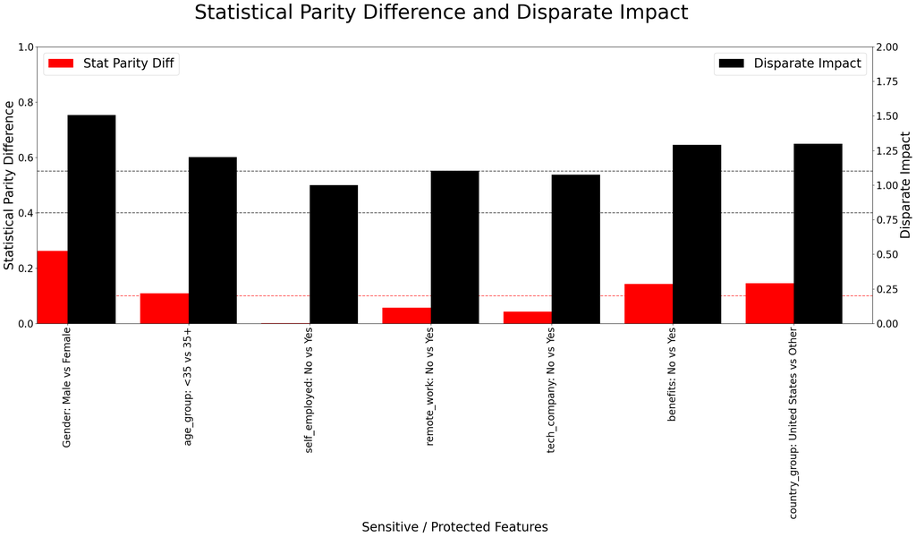

```python
fig = plt.figure() # Create matplotlib figure

ax = fig.add_subplot(111) # Create matplotlib axes
ax2 = ax.twinx() # Create another axes that shares the same x-axis as ax.


fig.suptitle('Statistical Parity Difference and Disparate Impact', fontsize=40, y=1)


width = 0.4
d.plot(x ='Protected_feature', y='SP_normal', kind = 'bar', ax=ax, width=width,
       position=1, color='red', legend=False, figsize=(30,10), fontsize=20)

d.plot(x ='Protected_feature', y='DI_normal', kind = 'bar', ax=ax2, width=width,
       position=0, color='black', legend=False, figsize=(30,10), fontsize=20)

ax.axhline(y=0.1, linestyle='dashed', alpha=0.7, color='red')
ax2.axhline(y=1.10, linestyle='dashed', alpha=0.7, color='black')


patches, labels = ax.get_legend_handles_labels()
ax.legend(patches, ['Stat Parity Diff'], loc='upper left', fontsize=25)

patches, labels = ax2.get_legend_handles_labels()
ax2.legend(patches, ['Disparate Impact'], loc='upper right', fontsize=25)


ax2.axhline(y=.80, linestyle='dashed', alpha=0.7, color='black')

ax.set_xlabel('Sensitive / Protected Features', fontsize=25)

ax.set_ylabel('Statistical Parity Difference', fontsize=25)
ax2.set_ylabel('Disparate Impact', fontsize=25)

# Increase bar height limit
ax.set_ylim(0, 1)
ax2.set_ylim(0, 2)

plt.show()
```

### Frequency for sensitive features

```python
for groupe in range(0, len(protected_attribute_names)):
    protected_attribute_name = list(privileged_groups[groupe].keys())[0]
    # print(protected_attribute_name)
    print(data[protected_attribute_name].value_counts())
    print ("-------------------------------------")
```

```
Gender
Male      559
Female    136
Name: count, dtype: int64
-------------------------------------
age_group
<35    474
35+    221
Name: count, dtype: int64
-------------------------------------
self_employed
No     588
Yes     97
Name: count, dtype: int64
-------------------------------------
remote_work
No     488
Yes    207
Name: count, dtype: int64
-------------------------------------
tech_company
Yes    564
No     131
Name: count, dtype: int64
-------------------------------------
benefits
Yes    370
No     325
Name: count, dtype: int64
-------------------------------------
country_group
United States    400
Other            295
Name: count, dtype: int64
-------------------------------------
```

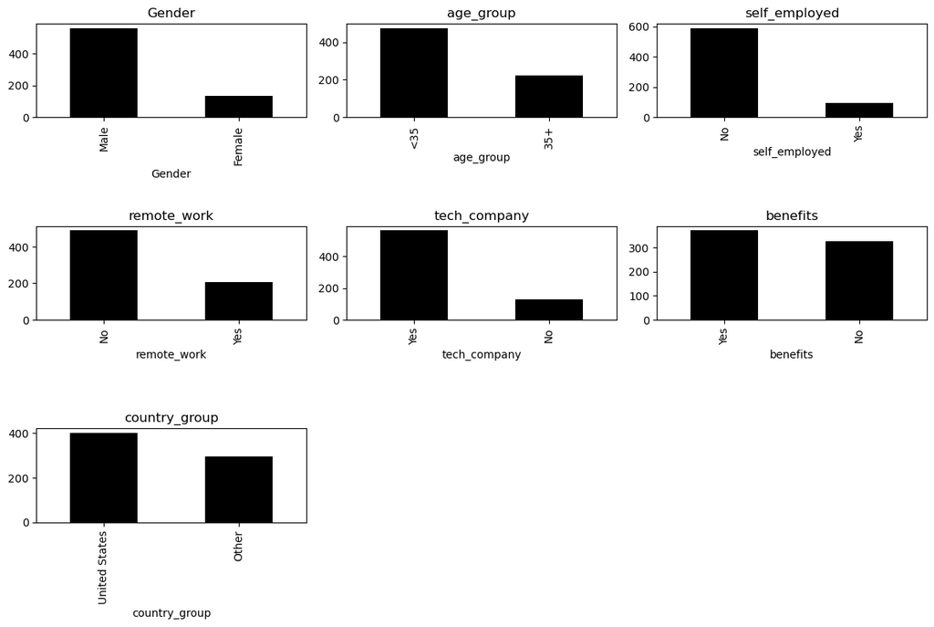

```python
fig = plt.figure()

for groupe in range(0, len(protected_attribute_names)):
    #plt.figure(figsize = (4,2))
    protected_attribute_name = list(privileged_groups[groupe].keys())[0]
    #data[protected_attribute_name].value_counts().plot(kind='bar')
    ax = fig.add_subplot(5,3,groupe+1)


    vc=data[protected_attribute_name].value_counts()
    ax=vc.plot(kind='bar', figsize=(12,12), title=protected_attribute_name, color = 'black')
    #axes.plot(vc)


plt.tight_layout()
plt.show()
```

## 4. Cross-tabs Analysis

To further explore the relationship between protected attributes and mental health treatment-seeking by:

- **Visualizing raw group sizes and outcome rates**
- **Identifying patterns or outliers**
- **Support interpretation of bias metrics**: These crosstabs clarify whether observed disparities are driven by large, balanced groups or by small subpopulations.

### Cross-tabs for sensitive features

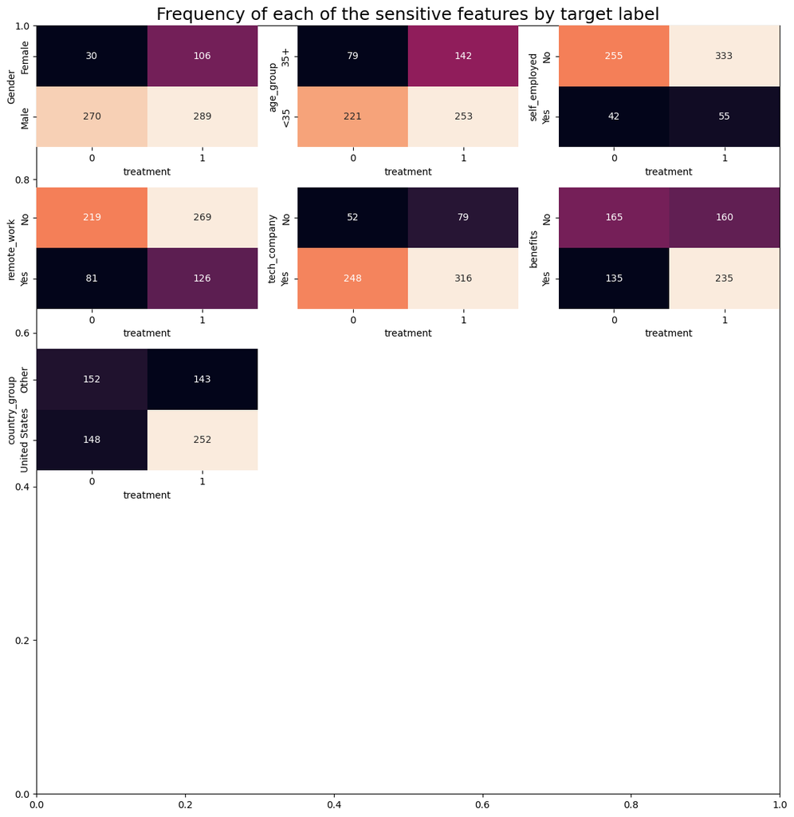

```python
#fig = plt.figure()
fig, ax = plt.subplots(figsize=(12,12))
#plt.suptitle('lalala')
ax.set_title("Frequency of each of the sensitive features by target label", fontsize=18)


for groupe in range(0, len(protected_attribute_names)):
    #_,ax = plt.figure(figsize = (8,8))
    protected_attribute_name = list(privileged_groups[groupe].keys())[0]
    #data[protected_attribute_name].value_counts().plot(kind='bar')
    ax = fig.add_subplot(5,3,groupe+1)

    plotdf=pd.crosstab(data[protected_attribute_name], data['treatment'])
    ax=sns.heatmap(plotdf, annot=True, fmt='g', cbar=False, ax=ax)    #axes.plot(vc)
    #print (type(axes))


plt.tight_layout()
plt.show()
```

### Calculation for Statistical Parity and Disparate Impact for a given protected feature

```python
choice = 'Gender'
pval = 'Male' #privileged : see the above heatmaps
upval = 'Female' #Unprivileged
```

```python
# label_names=['Default']
label_names=['treatment']
protected_attribute_names=[choice]
privileged_groups=[{choice: pval}]
unprivileged_groups=[{choice: upval }]
```

```python
stat_parity, disprate_impact = stat_parity_test(data, protected_attribute_name=choice, label='treatment', fav=1,
              privileged_group_protected_attribute_value=pval, unprivileged_group_protected_attribute_value=upval)
```

```
Statistical Parity Difference 0.2624171314321794
Disparate Impact 1.5075819255037657
```

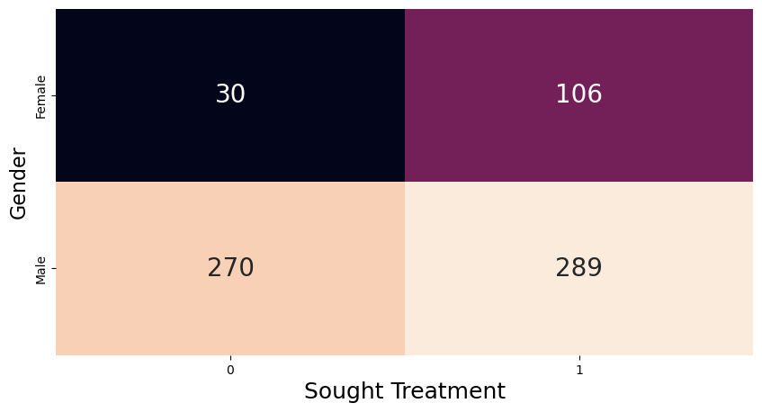

```python
plt.subplots(figsize=(10,5))
plotdf=pd.crosstab(data[choice], data['treatment'], rownames=['choice'])
ax=sns.heatmap(plotdf, annot=True, fmt='g', cbar=False, annot_kws={'size':20})    #axes.plot(vc)
plt.xlabel('Sought Treatment', fontsize=18)
plt.ylabel(choice, fontsize=16)

plt.show()    #axes.plot(vc)
plt.show()
```

## 5. Interpretation & Implications for Responsible AI

- **Groups with higher statistical parity difference or disparate impact** are systematically more or less likely to seek treatment, which may reflect underlying societal, structural, or workplace barriers.
- **Potential causes** include cultural stigma, lack of resources, or uneven support across organizations and countries.

**Implications:**

- **For practitioners:** Predictive models trained on this data may inherit or amplify these biases, leading to unfair recommendations or interventions for underrepresented groups.
- **For organizations:** There is a need for targeted outreach and policy changes to ensure equitable access to mental health resources.
- **For data scientists:** Regular fairness audits are crucial to identify and mitigate hidden biases before deploying machine learning solutions.

*These results emphasize the importance of responsible AI practices and ongoing fairness monitoring in real-world applications, especially in sensitive domains like mental health.*